# Risk Factor Analysis

## Outcome Variable

**Outcome Variable:** pers_wast

## Predictor Variables

**Intervention Variable:** gagebrth

**Adjustment Set:**

- arm
- sex
- W_mage
- W_fage
- meducyrs
- feducyrs
- single
- brthmon
- delta_W_mage
- delta_W_fage
- delta_meducyrs
- delta_feducyrs
- delta_single
- delta_brthmon

## Stratifying Variables

The analysis was stratified on these variable(s):

- agecat
- studyid
- country

## Data Summary

| agecat | studyid | country | gagebrth | pers_wast | n_cell | n |
| --- | --- | --- | --- | --- | --- | --- |
| 0-24 months | CMC-V-BCS-2002 | INDIA | Full or late term | 0 | 201 | 351 |
| 0-24 months | CMC-V-BCS-2002 | INDIA | Full or late term | 1 | 14 | 351 |
| 0-24 months | CMC-V-BCS-2002 | INDIA | Preterm | 0 | 49 | 351 |
| 0-24 months | CMC-V-BCS-2002 | INDIA | Preterm | 1 | 3 | 351 |
| 0-24 months | CMC-V-BCS-2002 | INDIA | Early term | 0 | 81 | 351 |
| 0-24 months | CMC-V-BCS-2002 | INDIA | Early term | 1 | 3 | 351 |
| 0-24 months | COHORTS | GUATEMALA | Full or late term | 0 | 401 | 732 |
| 0-24 months | COHORTS | GUATEMALA | Full or late term | 1 | 8 | 732 |
| 0-24 months | COHORTS | GUATEMALA | Preterm | 0 | 113 | 732 |
| 0-24 months | COHORTS | GUATEMALA | Preterm | 1 | 6 | 732 |
| 0-24 months | COHORTS | GUATEMALA | Early term | 0 | 198 | 732 |
| 0-24 months | COHORTS | GUATEMALA | Early term | 1 | 6 | 732 |
| 0-24 months | COHORTS | INDIA | Full or late term | 0 | 470 | 1186 |
| 0-24 months | COHORTS | INDIA | Full or late term | 1 | 42 | 1186 |
| 0-24 months | COHORTS | INDIA | Preterm | 0 | 248 | 1186 |
| 0-24 months | COHORTS | INDIA | Preterm | 1 | 18 | 1186 |
| 0-24 months | COHORTS | INDIA | Early term | 0 | 367 | 1186 |
| 0-24 months | COHORTS | INDIA | Early term | 1 | 41 | 1186 |
| 0-24 months | COHORTS | PHILIPPINES | Full or late term | 0 | 1034 | 2789 |
| 0-24 months | COHORTS | PHILIPPINES | Full or late term | 1 | 47 | 2789 |
| 0-24 months | COHORTS | PHILIPPINES | Preterm | 0 | 550 | 2789 |
| 0-24 months | COHORTS | PHILIPPINES | Preterm | 1 | 34 | 2789 |
| 0-24 months | COHORTS | PHILIPPINES | Early term | 0 | 1062 | 2789 |
| 0-24 months | COHORTS | PHILIPPINES | Early term | 1 | 62 | 2789 |
| 0-24 months | IRC | INDIA | Full or late term | 0 | 225 | 390 |
| 0-24 months | IRC | INDIA | Full or late term | 1 | 25 | 390 |
| 0-24 months | IRC | INDIA | Preterm | 0 | 34 | 390 |
| 0-24 months | IRC | INDIA | Preterm | 1 | 8 | 390 |
| 0-24 months | IRC | INDIA | Early term | 0 | 85 | 390 |
| 0-24 months | IRC | INDIA | Early term | 1 | 13 | 390 |

[output cut: 138 more lines]

The following strata were considered:

- agecat: 0-24 months, studyid: CMC-V-BCS-2002, country: INDIA
- agecat: 0-24 months, studyid: COHORTS, country: GUATEMALA
- agecat: 0-24 months, studyid: COHORTS, country: INDIA
- agecat: 0-24 months, studyid: COHORTS, country: PHILIPPINES
- agecat: 0-24 months, studyid: IRC, country: INDIA
- agecat: 0-24 months, studyid: JiVitA-3, country: BANGLADESH
- agecat: 0-24 months, studyid: Keneba, country: GAMBIA
- agecat: 0-24 months, studyid: NIH-Crypto, country: BANGLADESH
- agecat: 0-24 months, studyid: PROBIT, country: BELARUS
- agecat: 0-24 months, studyid: TanzaniaChild2, country: TANZANIA, UNITED REPUBLIC OF
- agecat: 0-6 months, studyid: CMC-V-BCS-2002, country: INDIA
- agecat: 0-6 months, studyid: COHORTS, country: PHILIPPINES
- agecat: 0-6 months, studyid: IRC, country: INDIA
- agecat: 0-6 months, studyid: JiVitA-3, country: BANGLADESH
- agecat: 0-6 months, studyid: Keneba, country: GAMBIA
- agecat: 0-6 months, studyid: NIH-Crypto, country: BANGLADESH
- agecat: 0-6 months, studyid: PROBIT, country: BELARUS
- agecat: 0-6 months, studyid: TanzaniaChild2, country: TANZANIA, UNITED REPUBLIC OF
- agecat: 6-24 months, studyid: CMC-V-BCS-2002, country: INDIA
- agecat: 6-24 months, studyid: COHORTS, country: GUATEMALA
- agecat: 6-24 months, studyid: COHORTS, country: INDIA
- agecat: 6-24 months, studyid: COHORTS, country: PHILIPPINES
- agecat: 6-24 months, studyid: IRC, country: INDIA
- agecat: 6-24 months, studyid: JiVitA-3, country: BANGLADESH
- agecat: 6-24 months, studyid: Keneba, country: GAMBIA
- agecat: 6-24 months, studyid: NIH-Crypto, country: BANGLADESH
- agecat: 6-24 months, studyid: PROBIT, country: BELARUS
- agecat: 6-24 months, studyid: TanzaniaChild2, country: TANZANIA, UNITED REPUBLIC OF

### Dropped Strata

Some strata were dropped due to rare outcomes:

- agecat: 0-24 months, studyid: CMC-V-BCS-2002, country: INDIA
- agecat: 0-24 months, studyid: NIH-Crypto, country: BANGLADESH
- agecat: 0-6 months, studyid: JiVitA-3, country: BANGLADESH
- agecat: 0-6 months, studyid: NIH-Crypto, country: BANGLADESH
- agecat: 6-24 months, studyid: CMC-V-BCS-2002, country: INDIA
- agecat: 6-24 months, studyid: NIH-Crypto, country: BANGLADESH

## Methods Detail

We’re interested in the causal parameters $E[Y_a]$ for all values of $a \in \mathcal{A}$. These parameters represent the mean outcome if, possibly contrary to fact, we intervened to set all units to have $A=a$. Under the randomization and positivity assumptions, these are identified by the statistical parameters $\psi_a=E_W[E_{Y|A,W}(Y|A=a,W)]$. In addition, we’re interested in the mean of $Y$, $E[Y]$ under no intervention (the observed mean). We will estimate these parameters by using SuperLearner to fit the relevant likelihood factors – $E_{Y|A,W}(Y|A=a,W)$ and $p(A=a|W)$, and then updating our likelihood fit using a joint TMLE.

For unadjusted analyses ($W=\{\}$), initial likelihoods were estimated using Lrnr_glm to estimate the simple $E(Y|A)$ and Lrnr_mean to estimate $p(A)$. For adjusted analyses, a small library containing Lrnr_glmnet, Lrnr_xgboost, and Lrnr_mean was used.

Having estimated these parameters, we will then use the delta method to estimate relative risks and attributable risks relative to a prespecified baseline level of $A$.

# Results Detail

## Results Plots

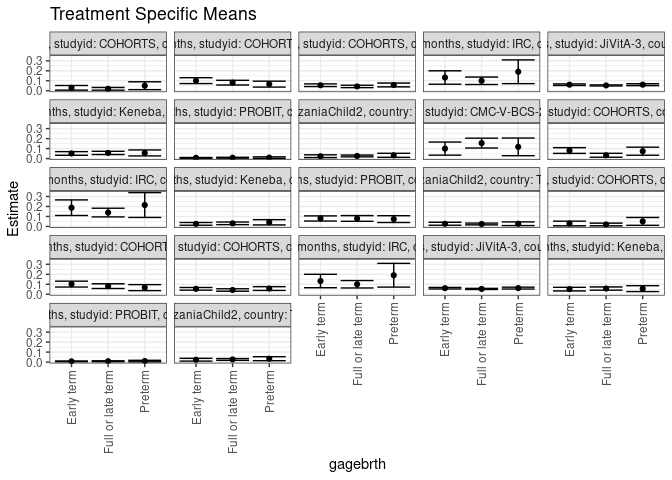

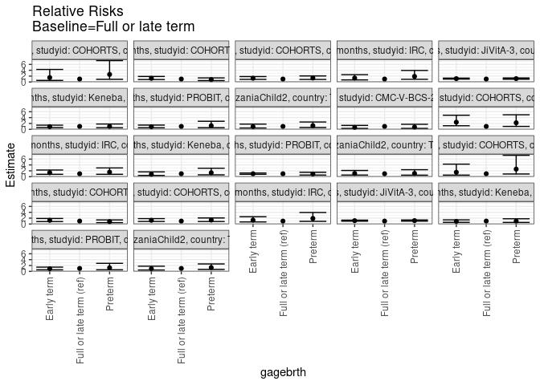

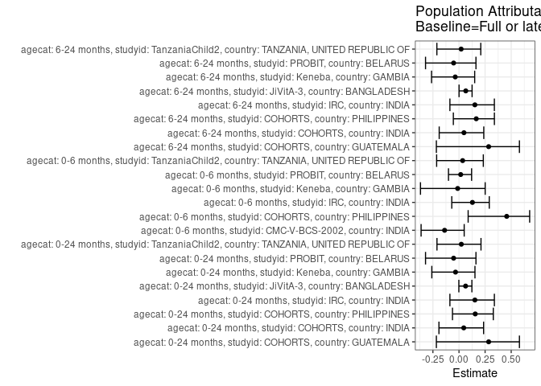

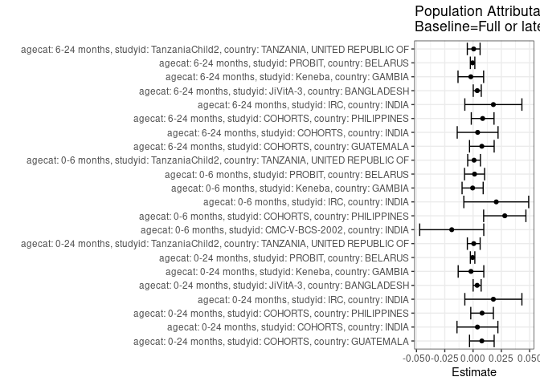

## Results Table

### Parameter: TSM

| agecat | studyid | country | intervention_level | baseline_level | estimate | ci_lower | ci_upper |
| --- | --- | --- | --- | --- | --- | --- | --- |
| 0-24 months | COHORTS | GUATEMALA | Full or late term | NA | 0.0195599 | 0.0061299 | 0.0329899 |
| 0-24 months | COHORTS | GUATEMALA | Preterm | NA | 0.0504202 | 0.0110797 | 0.0897606 |
| 0-24 months | COHORTS | GUATEMALA | Early term | NA | 0.0294118 | 0.0062107 | 0.0526128 |
| 0-24 months | COHORTS | INDIA | Full or late term | NA | 0.0812885 | 0.0576311 | 0.1049459 |
| 0-24 months | COHORTS | INDIA | Preterm | NA | 0.0663348 | 0.0364354 | 0.0962342 |
| 0-24 months | COHORTS | INDIA | Early term | NA | 0.1012606 | 0.0718684 | 0.1306529 |
| 0-24 months | COHORTS | PHILIPPINES | Full or late term | NA | 0.0433034 | 0.0311468 | 0.0554601 |
| 0-24 months | COHORTS | PHILIPPINES | Preterm | NA | 0.0580971 | 0.0390432 | 0.0771511 |
| 0-24 months | COHORTS | PHILIPPINES | Early term | NA | 0.0551603 | 0.0417995 | 0.0685210 |
| 0-24 months | IRC | INDIA | Full or late term | NA | 0.1000000 | 0.0627645 | 0.1372355 |
| 0-24 months | IRC | INDIA | Preterm | NA | 0.1904762 | 0.0715668 | 0.3093856 |
| 0-24 months | IRC | INDIA | Early term | NA | 0.1326531 | 0.0654100 | 0.1998961 |
| 0-24 months | JiVitA-3 | BANGLADESH | Full or late term | NA | 0.0534124 | 0.0479372 | 0.0588875 |
| 0-24 months | JiVitA-3 | BANGLADESH | Preterm | NA | 0.0610206 | 0.0516393 | 0.0704020 |
| 0-24 months | JiVitA-3 | BANGLADESH | Early term | NA | 0.0607430 | 0.0530086 | 0.0684775 |
| 0-24 months | Keneba | GAMBIA | Full or late term | NA | 0.0569295 | 0.0407069 | 0.0731522 |
| 0-24 months | Keneba | GAMBIA | Preterm | NA | 0.0565030 | 0.0267239 | 0.0862821 |
| 0-24 months | Keneba | GAMBIA | Early term | NA | 0.0514470 | 0.0331800 | 0.0697140 |
| 0-24 months | PROBIT | BELARUS | Full or late term | NA | 0.0084976 | 0.0040221 | 0.0129731 |
| 0-24 months | PROBIT | BELARUS | Preterm | NA | 0.0103448 | 0.0029413 | 0.0177483 |
| 0-24 months | PROBIT | BELARUS | Early term | NA | 0.0074369 | 0.0037707 | 0.0111031 |
| 0-24 months | TanzaniaChild2 | TANZANIA, UNITED REPUBLIC OF | Full or late term | NA | 0.0264238 | 0.0174808 | 0.0353668 |
| 0-24 months | TanzaniaChild2 | TANZANIA, UNITED REPUBLIC OF | Preterm | NA | 0.0327149 | 0.0125667 | 0.0528631 |
| 0-24 months | TanzaniaChild2 | TANZANIA, UNITED REPUBLIC OF | Early term | NA | 0.0237622 | 0.0098553 | 0.0376690 |
| 0-6 months | CMC-V-BCS-2002 | INDIA | Full or late term | NA | 0.1553398 | 0.1058014 | 0.2048782 |
| 0-6 months | CMC-V-BCS-2002 | INDIA | Preterm | NA | 0.1176471 | 0.0290906 | 0.2062035 |
| 0-6 months | CMC-V-BCS-2002 | INDIA | Early term | NA | 0.1000000 | 0.0341631 | 0.1658369 |
| 0-6 months | COHORTS | PHILIPPINES | Full or late term | NA | 0.0332970 | 0.0137909 | 0.0528031 |
| 0-6 months | COHORTS | PHILIPPINES | Preterm | NA | 0.0740556 | 0.0334946 | 0.1146166 |
| 0-6 months | COHORTS | PHILIPPINES | Early term | NA | 0.0806849 | 0.0520171 | 0.1093528 |
| 0-6 months | IRC | INDIA | Full or late term | NA | 0.1387755 | 0.0954297 | 0.1821213 |
| 0-6 months | IRC | INDIA | Preterm | NA | 0.2142857 | 0.0900289 | 0.3385425 |
| 0-6 months | IRC | INDIA | Early term | NA | 0.1875000 | 0.1093206 | 0.2656794 |
| 0-6 months | Keneba | GAMBIA | Full or late term | NA | 0.0309278 | 0.0179016 | 0.0439541 |
| 0-6 months | Keneba | GAMBIA | Preterm | NA | 0.0412844 | 0.0148657 | 0.0677031 |
| 0-6 months | Keneba | GAMBIA | Early term | NA | 0.0254403 | 0.0117832 | 0.0390974 |
| 0-6 months | PROBIT | BELARUS | Full or late term | NA | 0.0797349 | 0.0511224 | 0.1083473 |
| 0-6 months | PROBIT | BELARUS | Preterm | NA | 0.0734266 | 0.0392000 | 0.1076531 |
| 0-6 months | PROBIT | BELARUS | Early term | NA | 0.0798157 | 0.0540597 | 0.1055717 |
| 0-6 months | TanzaniaChild2 | TANZANIA, UNITED REPUBLIC OF | Full or late term | NA | 0.0244519 | 0.0156597 | 0.0332442 |
| 0-6 months | TanzaniaChild2 | TANZANIA, UNITED REPUBLIC OF | Preterm | NA | 0.0268456 | 0.0084896 | 0.0452017 |
| 0-6 months | TanzaniaChild2 | TANZANIA, UNITED REPUBLIC OF | Early term | NA | 0.0266667 | 0.0117775 | 0.0415558 |
| 6-24 months | COHORTS | GUATEMALA | Full or late term | NA | 0.0195599 | 0.0061299 | 0.0329899 |
| 6-24 months | COHORTS | GUATEMALA | Preterm | NA | 0.0504202 | 0.0110797 | 0.0897606 |
| 6-24 months | COHORTS | GUATEMALA | Early term | NA | 0.0294118 | 0.0062107 | 0.0526128 |
| 6-24 months | COHORTS | INDIA | Full or late term | NA | 0.0811152 | 0.0574942 | 0.1047361 |
| 6-24 months | COHORTS | INDIA | Preterm | NA | 0.0662977 | 0.0363291 | 0.0962663 |
| 6-24 months | COHORTS | INDIA | Early term | NA | 0.1016869 | 0.0722224 | 0.1311515 |
| 6-24 months | COHORTS | PHILIPPINES | Full or late term | NA | 0.0427989 | 0.0305844 | 0.0550133 |
| 6-24 months | COHORTS | PHILIPPINES | Preterm | NA | 0.0570867 | 0.0380854 | 0.0760880 |
| 6-24 months | COHORTS | PHILIPPINES | Early term | NA | 0.0541808 | 0.0408116 | 0.0675499 |
| 6-24 months | IRC | INDIA | Full or late term | NA | 0.1000000 | 0.0627645 | 0.1372355 |
| 6-24 months | IRC | INDIA | Preterm | NA | 0.1904762 | 0.0715668 | 0.3093856 |
| 6-24 months | IRC | INDIA | Early term | NA | 0.1326531 | 0.0654100 | 0.1998961 |
| 6-24 months | JiVitA-3 | BANGLADESH | Full or late term | NA | 0.0533075 | 0.0478475 | 0.0587675 |
| 6-24 months | JiVitA-3 | BANGLADESH | Preterm | NA | 0.0618746 | 0.0525081 | 0.0712410 |
| 6-24 months | JiVitA-3 | BANGLADESH | Early term | NA | 0.0607446 | 0.0529698 | 0.0685195 |
| 6-24 months | Keneba | GAMBIA | Full or late term | NA | 0.0570803 | 0.0408426 | 0.0733179 |
| 6-24 months | Keneba | GAMBIA | Preterm | NA | 0.0562764 | 0.0267479 | 0.0858048 |
| 6-24 months | Keneba | GAMBIA | Early term | NA | 0.0515337 | 0.0332359 | 0.0698315 |
| 6-24 months | PROBIT | BELARUS | Full or late term | NA | 0.0084976 | 0.0040221 | 0.0129731 |
| 6-24 months | PROBIT | BELARUS | Preterm | NA | 0.0103448 | 0.0029413 | 0.0177483 |
| 6-24 months | PROBIT | BELARUS | Early term | NA | 0.0074369 | 0.0037707 | 0.0111031 |
| 6-24 months | TanzaniaChild2 | TANZANIA, UNITED REPUBLIC OF | Full or late term | NA | 0.0264684 | 0.0175391 | 0.0353976 |
| 6-24 months | TanzaniaChild2 | TANZANIA, UNITED REPUBLIC OF | Preterm | NA | 0.0340431 | 0.0140356 | 0.0540506 |
| 6-24 months | TanzaniaChild2 | TANZANIA, UNITED REPUBLIC OF | Early term | NA | 0.0237174 | 0.0098816 | 0.0375532 |

### Parameter: E(Y)

| agecat | studyid | country | intervention_level | baseline_level | estimate | ci_lower | ci_upper |
| --- | --- | --- | --- | --- | --- | --- | --- |
| 0-24 months | COHORTS | GUATEMALA | NA | NA | 0.0273224 | 0.0155047 | 0.0391401 |
| 0-24 months | COHORTS | INDIA | NA | NA | 0.0851602 | 0.0692682 | 0.1010522 |
| 0-24 months | COHORTS | PHILIPPINES | NA | NA | 0.0512729 | 0.0430860 | 0.0594597 |
| 0-24 months | IRC | INDIA | NA | NA | 0.1179487 | 0.0858959 | 0.1500016 |
| 0-24 months | JiVitA-3 | BANGLADESH | NA | NA | 0.0570138 | 0.0528460 | 0.0611815 |
| 0-24 months | Keneba | GAMBIA | NA | NA | 0.0550982 | 0.0438403 | 0.0663560 |
| 0-24 months | PROBIT | BELARUS | NA | NA | 0.0080806 | 0.0045539 | 0.0116073 |
| 0-24 months | TanzaniaChild2 | TANZANIA, UNITED REPUBLIC OF | NA | NA | 0.0270270 | 0.0199797 | 0.0340743 |
| 0-6 months | CMC-V-BCS-2002 | INDIA | NA | NA | 0.1364985 | 0.0997894 | 0.1732076 |
| 0-6 months | COHORTS | PHILIPPINES | NA | NA | 0.0613208 | 0.0451635 | 0.0774781 |
| 0-6 months | IRC | INDIA | NA | NA | 0.1592689 | 0.1225736 | 0.1959642 |
| 0-6 months | Keneba | GAMBIA | NA | NA | 0.0305398 | 0.0215490 | 0.0395306 |
| 0-6 months | PROBIT | BELARUS | NA | NA | 0.0810551 | 0.0555982 | 0.1065120 |
| 0-6 months | TanzaniaChild2 | TANZANIA, UNITED REPUBLIC OF | NA | NA | 0.0253361 | 0.0183307 | 0.0323414 |
| 6-24 months | COHORTS | GUATEMALA | NA | NA | 0.0273224 | 0.0155047 | 0.0391401 |
| 6-24 months | COHORTS | INDIA | NA | NA | 0.0851602 | 0.0692682 | 0.1010522 |
| 6-24 months | COHORTS | PHILIPPINES | NA | NA | 0.0512729 | 0.0430860 | 0.0594597 |
| 6-24 months | IRC | INDIA | NA | NA | 0.1179487 | 0.0858959 | 0.1500016 |
| 6-24 months | JiVitA-3 | BANGLADESH | NA | NA | 0.0570138 | 0.0528460 | 0.0611815 |
| 6-24 months | Keneba | GAMBIA | NA | NA | 0.0550982 | 0.0438403 | 0.0663560 |
| 6-24 months | PROBIT | BELARUS | NA | NA | 0.0080806 | 0.0045539 | 0.0116073 |
| 6-24 months | TanzaniaChild2 | TANZANIA, UNITED REPUBLIC OF | NA | NA | 0.0270270 | 0.0199797 | 0.0340743 |

### Parameter: RR

| agecat | studyid | country | intervention_level | baseline_level | estimate | ci_lower | ci_upper |
| --- | --- | --- | --- | --- | --- | --- | --- |
| 0-24 months | COHORTS | GUATEMALA | Full or late term | Full or late term | 1.0000000 | 1.0000000 | 1.000000 |
| 0-24 months | COHORTS | GUATEMALA | Preterm | Full or late term | 2.5777311 | 0.9117126 | 7.288149 |
| 0-24 months | COHORTS | GUATEMALA | Early term | Full or late term | 1.5036765 | 0.5284081 | 4.278971 |
| 0-24 months | COHORTS | INDIA | Full or late term | Full or late term | 1.0000000 | 1.0000000 | 1.000000 |
| 0-24 months | COHORTS | INDIA | Preterm | Full or late term | 0.8160414 | 0.4774846 | 1.394650 |
| 0-24 months | COHORTS | INDIA | Early term | Full or late term | 1.2456949 | 0.8260118 | 1.878612 |
| 0-24 months | COHORTS | PHILIPPINES | Full or late term | Full or late term | 1.0000000 | 1.0000000 | 1.000000 |
| 0-24 months | COHORTS | PHILIPPINES | Preterm | Full or late term | 1.3416289 | 0.8713037 | 2.065833 |
| 0-24 months | COHORTS | PHILIPPINES | Early term | Full or late term | 1.2738084 | 0.8792378 | 1.845448 |
| 0-24 months | IRC | INDIA | Full or late term | Full or late term | 1.0000000 | 1.0000000 | 1.000000 |
| 0-24 months | IRC | INDIA | Preterm | Full or late term | 1.9047619 | 0.9207828 | 3.940254 |
| 0-24 months | IRC | INDIA | Early term | Full or late term | 1.3265306 | 0.7072263 | 2.488148 |
| 0-24 months | JiVitA-3 | BANGLADESH | Full or late term | Full or late term | 1.0000000 | 1.0000000 | 1.000000 |
| 0-24 months | JiVitA-3 | BANGLADESH | Preterm | Full or late term | 1.1424437 | 0.9514380 | 1.371795 |
| 0-24 months | JiVitA-3 | BANGLADESH | Early term | Full or late term | 1.1372467 | 0.9733410 | 1.328753 |
| 0-24 months | Keneba | GAMBIA | Full or late term | Full or late term | 1.0000000 | 1.0000000 | 1.000000 |
| 0-24 months | Keneba | GAMBIA | Preterm | Full or late term | 0.9925074 | 0.5450412 | 1.807333 |
| 0-24 months | Keneba | GAMBIA | Early term | Full or late term | 0.9036966 | 0.5731515 | 1.424872 |
| 0-24 months | PROBIT | BELARUS | Full or late term | Full or late term | 1.0000000 | 1.0000000 | 1.000000 |
| 0-24 months | PROBIT | BELARUS | Preterm | Full or late term | 1.2173851 | 0.5398571 | 2.745220 |
| 0-24 months | PROBIT | BELARUS | Early term | Full or late term | 0.8751808 | 0.5286513 | 1.448859 |
| 0-24 months | TanzaniaChild2 | TANZANIA, UNITED REPUBLIC OF | Full or late term | Full or late term | 1.0000000 | 1.0000000 | 1.000000 |
| 0-24 months | TanzaniaChild2 | TANZANIA, UNITED REPUBLIC OF | Preterm | Full or late term | 1.2380856 | 0.6131391 | 2.500013 |
| 0-24 months | TanzaniaChild2 | TANZANIA, UNITED REPUBLIC OF | Early term | Full or late term | 0.8992723 | 0.4574220 | 1.767931 |
| 0-6 months | CMC-V-BCS-2002 | INDIA | Full or late term | Full or late term | 1.0000000 | 1.0000000 | 1.000000 |
| 0-6 months | CMC-V-BCS-2002 | INDIA | Preterm | Full or late term | 0.7573529 | 0.3343982 | 1.715271 |
| 0-6 months | CMC-V-BCS-2002 | INDIA | Early term | Full or late term | 0.6437500 | 0.3097517 | 1.337891 |
| 0-6 months | COHORTS | PHILIPPINES | Full or late term | Full or late term | 1.0000000 | 1.0000000 | 1.000000 |
| 0-6 months | COHORTS | PHILIPPINES | Preterm | Full or late term | 2.2240918 | 0.9967240 | 4.962843 |
| 0-6 months | COHORTS | PHILIPPINES | Early term | Full or late term | 2.4231884 | 1.2205477 | 4.810825 |
| 0-6 months | IRC | INDIA | Full or late term | Full or late term | 1.0000000 | 1.0000000 | 1.000000 |
| 0-6 months | IRC | INDIA | Preterm | Full or late term | 1.5441176 | 0.7991678 | 2.983478 |
| 0-6 months | IRC | INDIA | Early term | Full or late term | 1.3511029 | 0.8024776 | 2.274804 |
| 0-6 months | Keneba | GAMBIA | Full or late term | Full or late term | 1.0000000 | 1.0000000 | 1.000000 |
| 0-6 months | Keneba | GAMBIA | Preterm | Full or late term | 1.3348624 | 0.6204803 | 2.871739 |
| 0-6 months | Keneba | GAMBIA | Early term | Full or late term | 0.8225701 | 0.4157567 | 1.627446 |
| 0-6 months | PROBIT | BELARUS | Full or late term | Full or late term | 1.0000000 | 1.0000000 | 1.000000 |
| 0-6 months | PROBIT | BELARUS | Preterm | Full or late term | 0.9208840 | 0.5602891 | 1.513553 |
| 0-6 months | PROBIT | BELARUS | Early term | Full or late term | 1.0010136 | 0.8052415 | 1.244382 |
| 0-6 months | TanzaniaChild2 | TANZANIA, UNITED REPUBLIC OF | Full or late term | Full or late term | 1.0000000 | 1.0000000 | 1.000000 |
| 0-6 months | TanzaniaChild2 | TANZANIA, UNITED REPUBLIC OF | Preterm | Full or late term | 1.0978940 | 0.5070474 | 2.377236 |
| 0-6 months | TanzaniaChild2 | TANZANIA, UNITED REPUBLIC OF | Early term | Full or late term | 1.0905747 | 0.5613548 | 2.118719 |
| 6-24 months | COHORTS | GUATEMALA | Full or late term | Full or late term | 1.0000000 | 1.0000000 | 1.000000 |
| 6-24 months | COHORTS | GUATEMALA | Preterm | Full or late term | 2.5777311 | 0.9117126 | 7.288149 |
| 6-24 months | COHORTS | GUATEMALA | Early term | Full or late term | 1.5036765 | 0.5284081 | 4.278971 |
| 6-24 months | COHORTS | INDIA | Full or late term | Full or late term | 1.0000000 | 1.0000000 | 1.000000 |
| 6-24 months | COHORTS | INDIA | Preterm | Full or late term | 0.8173281 | 0.4777689 | 1.398219 |
| 6-24 months | COHORTS | INDIA | Early term | Full or late term | 1.2536118 | 0.8315478 | 1.889900 |
| 6-24 months | COHORTS | PHILIPPINES | Full or late term | Full or late term | 1.0000000 | 1.0000000 | 1.000000 |
| 6-24 months | COHORTS | PHILIPPINES | Preterm | Full or late term | 1.3338369 | 0.8604526 | 2.067657 |
| 6-24 months | COHORTS | PHILIPPINES | Early term | Full or late term | 1.2659394 | 0.8679189 | 1.846489 |
| 6-24 months | IRC | INDIA | Full or late term | Full or late term | 1.0000000 | 1.0000000 | 1.000000 |
| 6-24 months | IRC | INDIA | Preterm | Full or late term | 1.9047619 | 0.9207828 | 3.940254 |
| 6-24 months | IRC | INDIA | Early term | Full or late term | 1.3265306 | 0.7072263 | 2.488148 |
| 6-24 months | JiVitA-3 | BANGLADESH | Full or late term | Full or late term | 1.0000000 | 1.0000000 | 1.000000 |
| 6-24 months | JiVitA-3 | BANGLADESH | Preterm | Full or late term | 1.1607104 | 0.9683448 | 1.391290 |
| 6-24 months | JiVitA-3 | BANGLADESH | Early term | Full or late term | 1.1395142 | 0.9748696 | 1.331965 |
| 6-24 months | Keneba | GAMBIA | Full or late term | Full or late term | 1.0000000 | 1.0000000 | 1.000000 |
| 6-24 months | Keneba | GAMBIA | Preterm | Full or late term | 0.9859162 | 0.5427304 | 1.791001 |
| 6-24 months | Keneba | GAMBIA | Early term | Full or late term | 0.9028290 | 0.5728408 | 1.422909 |
| 6-24 months | PROBIT | BELARUS | Full or late term | Full or late term | 1.0000000 | 1.0000000 | 1.000000 |
| 6-24 months | PROBIT | BELARUS | Preterm | Full or late term | 1.2173851 | 0.5398571 | 2.745220 |
| 6-24 months | PROBIT | BELARUS | Early term | Full or late term | 0.8751808 | 0.5286513 | 1.448859 |
| 6-24 months | TanzaniaChild2 | TANZANIA, UNITED REPUBLIC OF | Full or late term | Full or late term | 1.0000000 | 1.0000000 | 1.000000 |
| 6-24 months | TanzaniaChild2 | TANZANIA, UNITED REPUBLIC OF | Preterm | Full or late term | 1.2861794 | 0.6532504 | 2.532348 |
| 6-24 months | TanzaniaChild2 | TANZANIA, UNITED REPUBLIC OF | Early term | Full or late term | 0.8960662 | 0.4568342 | 1.757606 |

### Parameter: PAR

| agecat | studyid | country | intervention_level | baseline_level | estimate | ci_lower | ci_upper |
| --- | --- | --- | --- | --- | --- | --- | --- |
| 0-24 months | COHORTS | GUATEMALA | Full or late term | NA | 0.0077625 | -0.0031218 | 0.0186468 |
| 0-24 months | COHORTS | INDIA | Full or late term | NA | 0.0038717 | -0.0141992 | 0.0219426 |
| 0-24 months | COHORTS | PHILIPPINES | Full or late term | NA | 0.0079694 | -0.0020356 | 0.0179745 |
| 0-24 months | IRC | INDIA | Full or late term | NA | 0.0179487 | -0.0072768 | 0.0431742 |
| 0-24 months | JiVitA-3 | BANGLADESH | Full or late term | NA | 0.0036014 | 0.0000534 | 0.0071494 |
| 0-24 months | Keneba | GAMBIA | Full or late term | NA | -0.0018314 | -0.0131461 | 0.0094833 |
| 0-24 months | PROBIT | BELARUS | Full or late term | NA | -0.0004170 | -0.0023921 | 0.0015581 |
| 0-24 months | TanzaniaChild2 | TANZANIA, UNITED REPUBLIC OF | Full or late term | NA | 0.0006033 | -0.0050521 | 0.0062586 |
| 0-6 months | CMC-V-BCS-2002 | INDIA | Full or late term | NA | -0.0188413 | -0.0471504 | 0.0094678 |
| 0-6 months | COHORTS | PHILIPPINES | Full or late term | NA | 0.0280237 | 0.0093452 | 0.0467023 |
| 0-6 months | IRC | INDIA | Full or late term | NA | 0.0204934 | -0.0081709 | 0.0491577 |
| 0-6 months | Keneba | GAMBIA | Full or late term | NA | -0.0003881 | -0.0097080 | 0.0089318 |
| 0-6 months | PROBIT | BELARUS | Full or late term | NA | 0.0013202 | -0.0075399 | 0.0101804 |
| 0-6 months | TanzaniaChild2 | TANZANIA, UNITED REPUBLIC OF | Full or late term | NA | 0.0008842 | -0.0047344 | 0.0065027 |
| 6-24 months | COHORTS | GUATEMALA | Full or late term | NA | 0.0077625 | -0.0031218 | 0.0186468 |
| 6-24 months | COHORTS | INDIA | Full or late term | NA | 0.0040450 | -0.0139947 | 0.0220848 |
| 6-24 months | COHORTS | PHILIPPINES | Full or late term | NA | 0.0084740 | -0.0015778 | 0.0185258 |
| 6-24 months | IRC | INDIA | Full or late term | NA | 0.0179487 | -0.0072768 | 0.0431742 |
| 6-24 months | JiVitA-3 | BANGLADESH | Full or late term | NA | 0.0037063 | 0.0001578 | 0.0072547 |
| 6-24 months | Keneba | GAMBIA | Full or late term | NA | -0.0019821 | -0.0132964 | 0.0093321 |
| 6-24 months | PROBIT | BELARUS | Full or late term | NA | -0.0004170 | -0.0023921 | 0.0015581 |
| 6-24 months | TanzaniaChild2 | TANZANIA, UNITED REPUBLIC OF | Full or late term | NA | 0.0005587 | -0.0050842 | 0.0062015 |

### Parameter: PAF

| agecat | studyid | country | intervention_level | baseline_level | estimate | ci_lower | ci_upper |
| --- | --- | --- | --- | --- | --- | --- | --- |
| 0-24 months | COHORTS | GUATEMALA | Full or late term | NA | 0.2841076 | -0.2167890 | 0.5788079 |
| 0-24 months | COHORTS | INDIA | Full or late term | NA | 0.0454640 | -0.1920239 | 0.2356370 |
| 0-24 months | COHORTS | PHILIPPINES | Full or late term | NA | 0.1554318 | -0.0623780 | 0.3285860 |
| 0-24 months | IRC | INDIA | Full or late term | NA | 0.1521739 | -0.0870878 | 0.3387755 |
| 0-24 months | JiVitA-3 | BANGLADESH | Full or late term | NA | 0.0631668 | -0.0013631 | 0.1235383 |
| 0-24 months | Keneba | GAMBIA | Full or late term | NA | -0.0332384 | -0.2602861 | 0.1529054 |
| 0-24 months | PROBIT | BELARUS | Full or late term | NA | -0.0516073 | -0.3205094 | 0.1625369 |
| 0-24 months | TanzaniaChild2 | TANZANIA, UNITED REPUBLIC OF | Full or late term | NA | 0.0223203 | -0.2109558 | 0.2106585 |
| 0-6 months | CMC-V-BCS-2002 | INDIA | Full or late term | NA | -0.1380329 | -0.3629649 | 0.0497782 |
| 0-6 months | COHORTS | PHILIPPINES | Full or late term | NA | 0.4570026 | 0.0876470 | 0.6768288 |
| 0-6 months | IRC | INDIA | Full or late term | NA | 0.1286718 | -0.0692198 | 0.2899375 |
| 0-6 months | Keneba | GAMBIA | Full or late term | NA | -0.0127068 | -0.3688196 | 0.2507595 |
| 0-6 months | PROBIT | BELARUS | Full or late term | NA | 0.0162882 | -0.1006214 | 0.1207795 |
| 0-6 months | TanzaniaChild2 | TANZANIA, UNITED REPUBLIC OF | Full or late term | NA | 0.0348969 | -0.2141578 | 0.2328642 |
| 6-24 months | COHORTS | GUATEMALA | Full or late term | NA | 0.2841076 | -0.2167890 | 0.5788079 |
| 6-24 months | COHORTS | INDIA | Full or late term | NA | 0.0474991 | -0.1895816 | 0.2373302 |
| 6-24 months | COHORTS | PHILIPPINES | Full or late term | NA | 0.1652726 | -0.0541229 | 0.3390052 |
| 6-24 months | IRC | INDIA | Full or late term | NA | 0.1521739 | -0.0870878 | 0.3387755 |
| 6-24 months | JiVitA-3 | BANGLADESH | Full or late term | NA | 0.0650064 | 0.0004821 | 0.1253654 |
| 6-24 months | Keneba | GAMBIA | Full or late term | NA | -0.0359742 | -0.2629337 | 0.1501989 |
| 6-24 months | PROBIT | BELARUS | Full or late term | NA | -0.0516073 | -0.3205094 | 0.1625369 |
| 6-24 months | TanzaniaChild2 | TANZANIA, UNITED REPUBLIC OF | Full or late term | NA | 0.0206705 | -0.2119779 | 0.2086603 |